# Лабораторная работа 3. Вариант 8

Natalia Korskova

2016-04-06

### Сравнить расходы за год для больниц, расположенных в городе и за городом.

В описании дана следующая структура:

Variable Names:

BED = number of beds in home

MCDAYS = annual medical in-patient days (hundreds)

TDAYS = annual total patient days (hundreds)

PCREV = annual total patient care revenue ($hundreds)

NSAL = annual nursing salaries ($hundreds)

FEXP = annual facilities expenditures ($hundreds)

RURAL = rural (1) and non-rural (0) homes

Это значит, что последняя переменная является фактором, а остальные числами. Считываем данные согласно этой структуре:

```r
nursing <- read.table("Nursing Home Data_data", colClasses = c(rep("integer", 6), "factor"), header = TRUE)
```

Нас интересует переменная FEXP. Посмотрим на boxplot для расходов для подвыборок, полученных разбиением по признаку RURAL:

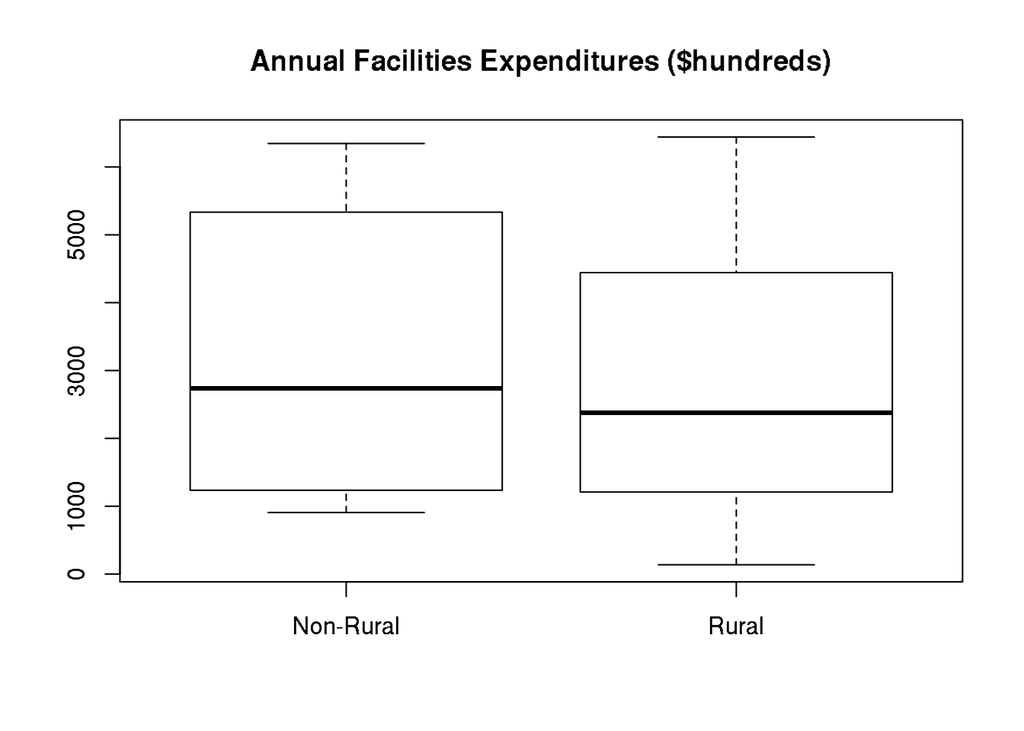

```r
rural <- nursing$FEXP[nursing$RURAL == 1]
non_rural <- nursing$FEXP[nursing$RURAL == 0]

boxplot(non_rural, rural, names = c("Non-Rural", "Rural"), main ="Annual Facilities Expenditures ($hundreds)")
```

Распределение расходов в городских больницах выглядит немного выше на графике boxplot – первые квантили примерно совпадают, медиана чуть выше, третий квантиль заметно выше. Описательные статистики:

```r
summary(non_rural)
```

```
##    Min. 1st Qu.  Median    Mean 3rd Qu.    Max.
##     907    1242    2737    3176    5058    6346
```

```r
summary(rural)
```

```
##    Min. 1st Qu.  Median    Mean 3rd Qu.    Max.
##     137    1217    2378    2674    4306    6442
```

Можно выдвинуть гипотезу о равенстве средних для городских больниц и больниц за городом, а в качестве альтернативы будет гипотеза о том, что среднее по расходам для городских больниц больше. Наши выборки являются независимыми, поэтому тест будет использоваться непарный (значение по умолчанию). Проверим гипотезу о равенстве дисперсий прежде чем пользоваться критерием Стьюдента:

```r
fligner.test(FEXP~RURAL, data=nursing)
```

```
##
##  Fligner-Killeen test of homogeneity of variances
##
## data:  FEXP by RURAL
## Fligner-Killeen:med chi-squared = 0.85485, df = 1, p-value =
## 0.3552
```

Значение p-value большое – нет оснований отклонять нулевую гипотезу о равенстве дисперсий. Тест Стьюдента для проверки гипотезы о равенстве среднего:

```r
t.test(non_rural, rural, alternative = "greater", var.equal = TRUE)
```

```
##
##  Two Sample t-test
##
## data:  non_rural and rural
## t = 0.8814, df = 50, p-value = 0.1912
## alternative hypothesis: true difference in means is greater than 0
## 95 percent confidence interval:
##  -452.371      Inf
## sample estimates:
## mean of x mean of y
##  3175.667  2673.824
```

Значение p-value около 0.2 – нет оснований отклонять нулевую гипотезу о равенстве средних для расходов по городским и сельским больницам.

Тест Уилкоксона тоже не отклоняет нулевую гипотезу:

```r
wilcox.test(non_rural, rural, alternative = "two.sided")
```

```
##
##  Wilcoxon rank sum test
##
## data:  non_rural and rural
## W = 339, p-value = 0.5355
## alternative hypothesis: true location shift is not equal to 0
```

Тест Муда для сравнения медиан:

```r
m_r <- median(nursing$FEXP)     # joint median
f11_r <- sum(rural > m_r)          # Pop.1 samples above median
f12_r <- sum(non_rural > m_r)
f21_r <- sum(rural <= m_r)         # Pop.1 samples below or at median
f22_r <- sum(non_rural <= m_r)
# 2x2 contingency table
table_r <- matrix(c(f11_r, f12_r, f21_r, f22_r), nrow=2, ncol=2)
chisq.test(table_r)
```

```
##
##  Pearson's Chi-squared test
##
## data:  table_r
## X-squared = 0, df = 1, p-value = 1
```

Нет оснований отклонять гипотезу о равенстве медиан – результаты всех тестов согласованы.

Изучим данные для того, чтобы выяснить, какой тест больше всего подходит. Для теста Стьюдента данные должны быть распределены нормально (или иметь близкое к нормальному распределение). Проверим нормальность данных для обеих подвыборок с помощью теста Шапиро-Уилка:

Больницы за городом:

```r
shapiro.test(rural)
```

```
##
##  Shapiro-Wilk normality test
##
## data:  rural
## W = 0.93372, p-value = 0.04018
```

Значение p-value 0.04: если взять уровень значимости 0.05, то гипотеза нормальности будет отклонена, а для уровня значимости 0.01 нет оснований отвергать нулевую гипотезу. Посмотрим на гистограмму распределения:

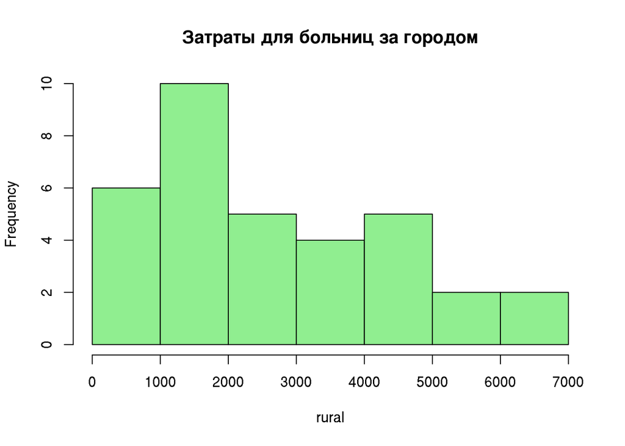

```r
hist(rural, col = "lightgreen", main = "Затраты для больниц за городом")
```

Не очень похоже на нормальное распределение – нет симметричности и колоколообразной формы.

Нормальность распределения больниц в городе:

```r
shapiro.test(non_rural)
```

```
##
##  Shapiro-Wilk normality test
##
## data:  non_rural
## W = 0.82863, p-value = 0.003969
```

Тест Шапиро-Уилка говорит о том, что распределение вряд ли нормальное – значение p-value очень маленькое и нулевая гипотеза отклоняется. Посмотрим на гистограмму:

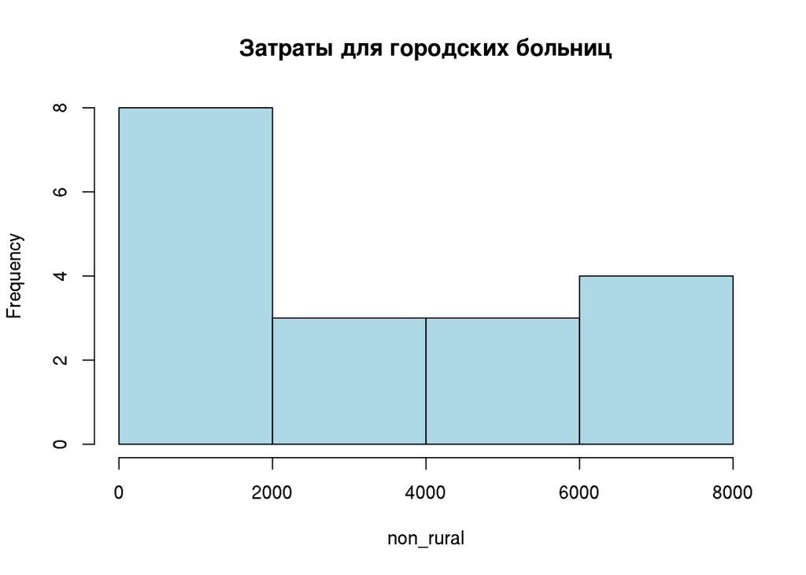

```r
hist(non_rural, col = "lightblue", main = "Затраты для городских больниц", breaks = 3)
```

Это распределение далеко от нормального. Тест Стьюдента не подходит.

Кроме теста Стьюдента были использованы тесты Манна-Уитни-Уилкоксона и Муда для равенства медиан. Критерий Муда требует достаточно большой выборки, у нас же выборки объёма 18 и 34, поэтому лучше этот критерий не использовать. Для критерия Манна-Уитни-Уилкоксона должны быть одинаковые распределения в подвыборках, сравним гистограммы:

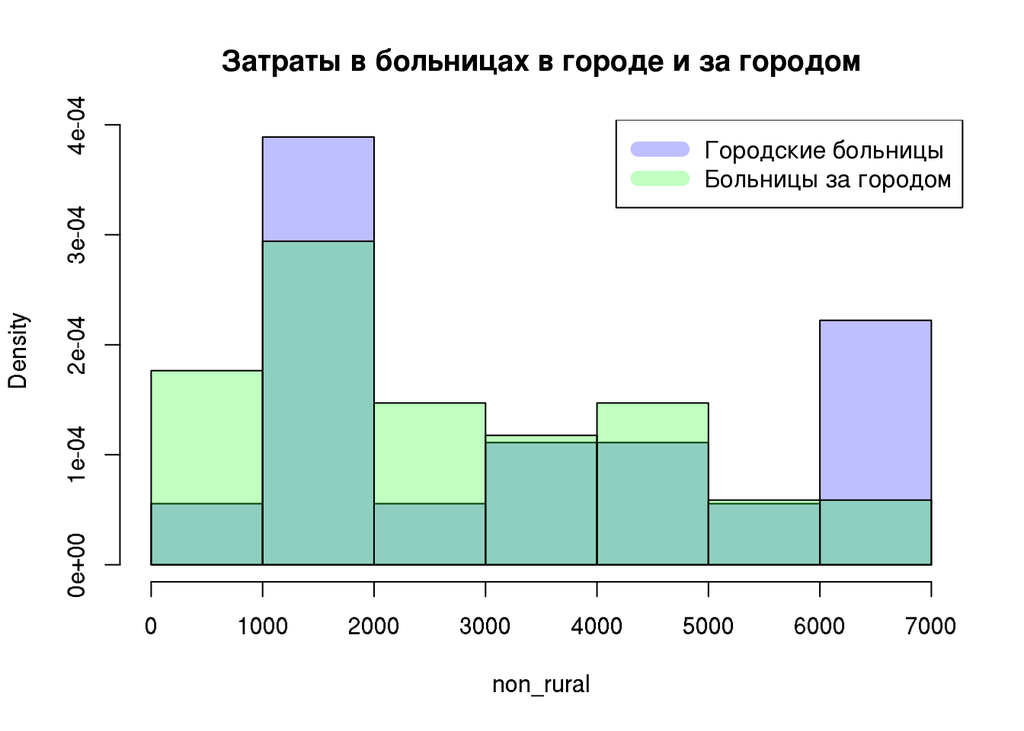

```r
hist(non_rural, freq = F, col=rgb(0,0,1,1/4), main = 'Затраты в больницах в городе и за городом')
hist(rural,freq = F, col=rgb(0,1,0,1/4), add=T)
legend("topright", c("Городские больницы", "Больницы за городом"), col = c(rgb(0,0,1,1/4), rgb(0,1,0,1/4)), lwd=10)
```

Можно сказать, что выборки имеют близкое распределение. Поэтому можно использовать критерий Манна-Уитни-Уилкоксона.

#### Вывод:

Для сравнения затрат в больницах за городом и в городе лучше всего использовать критерий Манна-Уитни-Уилкоксона, потому что распределения похожи. Критерий Стьюдента использовать нельзя, т.к. выборки не являются нормальными. Для критерия Муда недостаточен объём выборок. Критерий Манна-Уитни-Уилкоксона не отклоняет нулевую гипотезу о равенстве медиан.

### Сравнить процент брака на двух заводах компании (3 и 4).

Считываем данные, предварительно заметив, что пропущенные значения задаются символом “*“:

```r
waste <- read.table("Waste Run Up_data", header = TRUE, na.strings = "*")
```

Нас интересуют третий и четвёртый завод. Заведём для них переменные, отбросив NA:

```r
w_3 <- na.omit(waste$PT3)
w_4 <- na.omit(waste$PT4)
```

Описательные статистики для этих заводов и графики boxplot:

```r
summary(w_3)
```

```
##    Min. 1st Qu.  Median    Mean 3rd Qu.    Max.
##  -3.900   2.450   4.700   4.832   8.500  12.100
```

```r
summary(w_4)
```

```
##    Min. 1st Qu.  Median    Mean 3rd Qu.    Max.
##   0.700   5.150   7.100   7.489  10.200  14.500
```

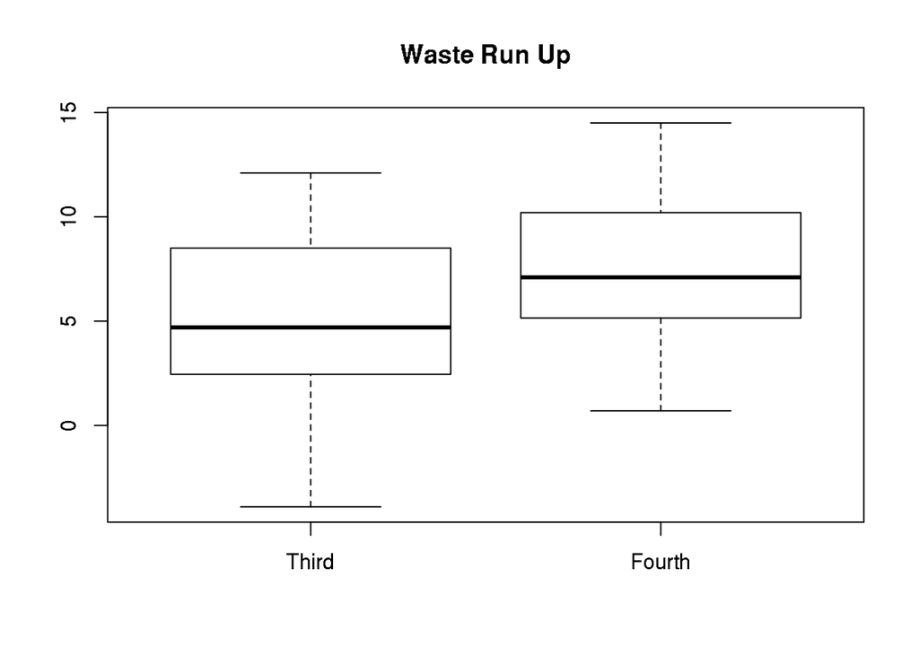

```r
boxplot(w_3, w_4, main="Waste Run Up", names = c("Third", "Fourth"))
```

Из статистик и графиков видно, что значения на четвёртом заводе выше. Будем проверять нулевую гипотезу о том, что среднее на третьем заводе равно среднему на четвёртом при альтернативной гипотезе о том, что на третьем заводе среднее ниже, чем на четвёртом. Проверим гипотезу о равенстве дисперсий.

```r
x <- c(w_3, w_4)
g <- c(rep(0, length(w_3)), rep(1, length(w_4)))
fligner.test(x~g)
```

```
##
##  Fligner-Killeen test of homogeneity of variances
##
## data:  x by g
## Fligner-Killeen:med chi-squared = 0.46695, df = 1, p-value =
## 0.4944
```

Нет оснований отклонять нулевую гипотезу о равенстве дисперсий. Критерий Стюдента для равенства средних:

```r
t.test(w_3, w_4, alternative = c("less"), var.equal = TRUE)
```

```
##
##  Two Sample t-test
##
## data:  w_3 and w_4
## t = -2.0241, df = 36, p-value = 0.02522
## alternative hypothesis: true difference in means is less than 0
## 95 percent confidence interval:
##        -Inf -0.4409314
## sample estimates:
## mean of x mean of y
##  4.831579  7.489474
```

Значение p-value 0.025 – если выбирать в качестве уровня значимости 0.05, то нулевая гипотеза о равенстве средних будет отклоняться и среднее на третьем заводе меньше, чем на четвёртом.

Критерий Уилкоксона не отклоняет нулевую гипотезу:

```r
wilcox.test(w_3, w_4, alternative = "two.sided")
```

```
##
##  Wilcoxon rank sum test with continuity correction
##
## data:  w_3 and w_4
## W = 117, p-value = 0.06583
## alternative hypothesis: true location shift is not equal to 0
```

Критерий Муда для сравнения медиан:

```r
m <- median(c(w_3, w_4))     # joint median
f11 <- sum(w_3 > m)          # Pop.1 samples above median
f12 <- sum(w_4 > m)
f21 <- sum(w_3 <= m)         # Pop.1 samples below or at median
f22 <- sum(w_4 <= m)
# 2x2 contingency table
table <- matrix(c(f11, f12, f21, f22), nrow=2, ncol=2)
chisq.test(table)
```

```
##
##  Pearson's Chi-squared test with Yates' continuity correction
##
## data:  table
## X-squared = 1.6842, df = 1, p-value = 0.1944
```

Нет оснований отклонять гипотезу о равенстве медиан. Критерий Муда требует достаточно больших объёмов выборок, а здесь выборки по 19 элементов. Изучим распределение выборок, чтобы сделать вывод о том, можно ли использовать другие критерии. Тест на нормальность:

```r
shapiro.test(w_3)
```

```
##
##  Shapiro-Wilk normality test
##
## data:  w_3
## W = 0.96948, p-value = 0.7661
```

Очень большое значение p-value – нет оснований отклонять гипотезу нормальности. Четвёртый завод:

```r
shapiro.test(w_4)
```

```
##
##  Shapiro-Wilk normality test
##
## data:  w_4
## W = 0.98813, p-value = 0.9956
```

Ещё больше значение p-value. Будем считать, что обе выборки нормальные, поэтому критерий Стьюдента можно использовать.

Обе выборки имеют нормальное распределение – критерий Манна-Уитни-Уилкоксона тоже можно использовать. Посмотрим на гистограммы:

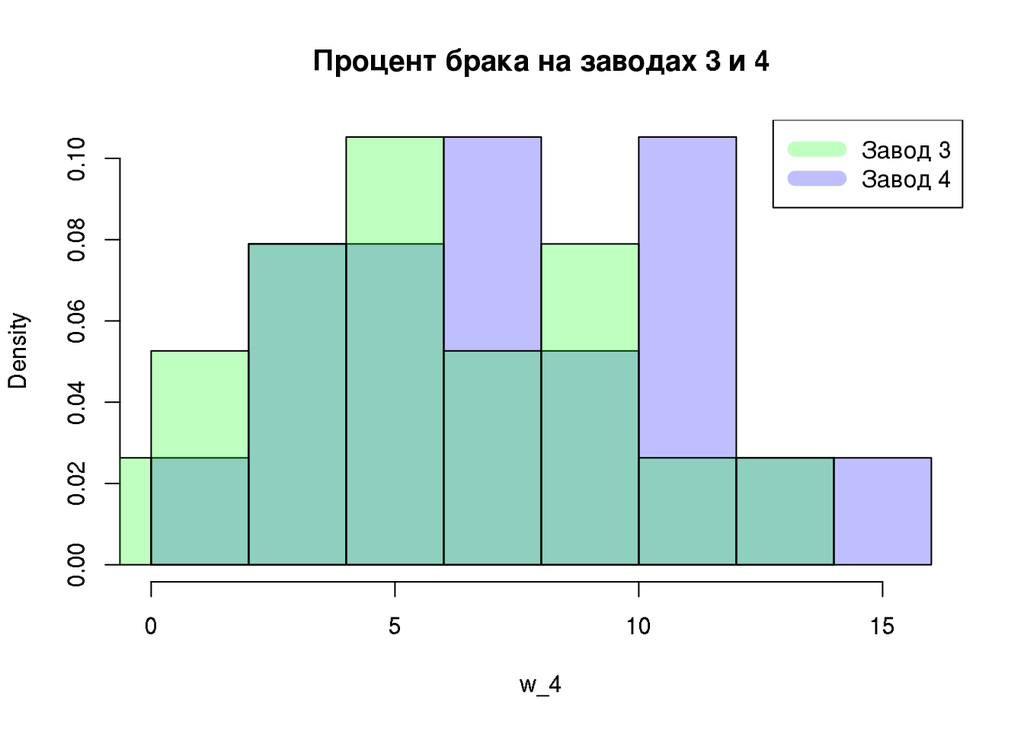

```r
hist(w_4, freq = F, col=rgb(0,0,1,1/4), main = 'Процент брака на заводах 3 и 4')
hist(w_3,freq = F, col=rgb(0,1,0,1/4), add=T)
legend("topright", c("Завод 3", "Завод 4"), col = c(rgb(0,1,0,1/4), rgb(0,0,1,1/4)), lwd=10)
```

Распределения похожи. Трактование результата критерия Манна-Уитни-Уилкоксона как показателя того, что выборки взяты из одной генеральной совокупности не противоречиво – все заводы принадлежат одной компании.

#### Вывод:

Для этой задачи можно применять критерий Стьюдента – обе выборки имеют нормальное распределение. По критерию Стьюдента среднее на третьем заводе меньше. Критерий Манна-Уитни-Уилкоксона тоже можно использовать, его результат – нет основания отвергать гипотезу о равенстве медиан. Для практического использования в этой задаче корректнее использовать критерий Стьюдента, его результат соотносится с данными.